# Latihan Modul 3 & 4

Rangga Restu Ramadhani

2022-09-14

Import dataset “murders”:

```r
library(dslabs)
library(tibble)
data(murders)
```

## MODUL 3

# Soal Nomor 1

Gunakan fungsi str untuk memeriksa struktur objek “murders”. Pernyataan yang paling menggambarkan karakter tiap variabel dalam data frame:

Data berisi Nama negara bagian, singkatan dari nama negara bagian, wilayah negara bagian, dan populasi negara bagian serta jumlah total pembunuhan pada tahun 2010.

```r
str(murders)
```

```
## 'data.frame':    51 obs. of  5 variables:
##  $ state     : chr  "Alabama" "Alaska" "Arizona" "Arkansas" ...
##  $ abb       : chr  "AL" "AK" "AZ" "AR" ...
##  $ region    : Factor w/ 4 levels "Northeast","South",..: 2 4 4 2 4 4 1 2 2 2 ...
##  $ population: num  4779736 710231 6392017 2915918 37253956 ...
##  $ total     : num  135 19 232 93 1257 ...
```

```r
as_tibble(murders)
```

```
## # A tibble: 51 × 5
##    state                abb   region    population total
##    <chr>                <chr> <fct>          <dbl> <dbl>
##  1 Alabama              AL    South        4779736   135
##  2 Alaska               AK    West          710231    19
##  3 Arizona              AZ    West         6392017   232
##  4 Arkansas             AR    South        2915918    93
##  5 California           CA    West        37253956  1257
##  6 Colorado             CO    West         5029196    65
##  7 Connecticut          CT    Northeast    3574097    97
##  8 Delaware             DE    South         897934    38
##  9 District of Columbia DC    South         601723    99
## 10 Florida              FL    South       19687653   669
## # … with 41 more rows
```

# Soal Nomor 2

Kolom yang digunakan dalam data frame.

```r
names(murders)
```

```
## [1] "state"      "abb"        "region"     "population" "total"
```

# Soal Nomor 3

Informasi singkatan negara menggunakan operator aksesor ($) dalam objek “a”

```r
a = murders$abb
char(a)
```

```
## <pillar_char[51]>
##  [1] AL AK AZ AR CA CO CT DE DC FL GA HI ID IL IN IA KS KY LA ME MD MA MI MN MS
## [26] MO MT NE NV NH NJ NM NY NC ND OH OK OR PA RI SC SD TN TX UT VT VA WA WV WI
## [51] WY
```

```r
class(a)
```

```
## [1] "character"
```

Jenis class objek “a” adalah character.

# Soal Nomor 4

Informasi suatu singkatan negara menggunakan tanda kurung siku dalam objek “b”

```r
b = murders$abb[51]
char(b)
```

```
## <pillar_char[1]>
## [1] WY
```

```r
class(b)
```

```
## [1] "character"
```

Kesimpulan: variabel “a” dan “b” bernilai sama, yaitu character.

# Soal Nomor 5

Fungsi level dan length pada variabel region.

```r
levels(murders$region); length(murders$region)
```

```
## [1] "Northeast"     "South"         "North Central" "West"
```

```
## [1] 51
```

# Soal Nomor 6

Fungsi tabel untuk menampilkan tabel berisi jumlah state pada setiap region.

```r
table(murders$state, murders$region)
```

```
##
##                        Northeast South North Central West
##   Alabama                      0     1             0    0
##   Alaska                       0     0             0    1
##   Arizona                      0     0             0    1
##   Arkansas                     0     1             0    0
##   California                   0     0             0    1
##   Colorado                     0     0             0    1
##   Connecticut                  1     0             0    0
##   Delaware                     0     1             0    0
##   District of Columbia         0     1             0    0
##   Florida                      0     1             0    0
##   Georgia                      0     1             0    0
##   Hawaii                       0     0             0    1
##   Idaho                        0     0             0    1
##   Illinois                     0     0             1    0
##   Indiana                      0     0             1    0
##   Iowa                         0     0             1    0
##   Kansas                       0     0             1    0
##   Kentucky                     0     1             0    0
##   Louisiana                    0     1             0    0
##   Maine                        1     0             0    0
##   Maryland                     0     1             0    0
##   Massachusetts                1     0             0    0
##   Michigan                     0     0             1    0
##   Minnesota                    0     0             1    0
##   Mississippi                  0     1             0    0
##   Missouri                     0     0             1    0
##   Montana                      0     0             0    1
##   Nebraska                     0     0             1    0
##   Nevada                       0     0             0    1
##   New Hampshire                1     0             0    0
##   New Jersey                   1     0             0    0
##   New Mexico                   0     0             0    1
##   New York                     1     0             0    0
##   North Carolina               0     1             0    0
##   North Dakota                 0     0             1    0
##   Ohio                         0     0             1    0
##   Oklahoma                     0     1             0    0
##   Oregon                       0     0             0    1
##   Pennsylvania                 1     0             0    0
##   Rhode Island                 1     0             0    0
##   South Carolina               0     1             0    0
##   South Dakota                 0     0             1    0
##   Tennessee                    0     1             0    0
##   Texas                        0     1             0    0
##   Utah                         0     0             0    1
##   Vermont                      1     0             0    0
##   Virginia                     0     1             0    0
##   Washington                   0     0             0    1
##   West Virginia                0     1             0    0
##   Wisconsin                    0     0             1    0
##   Wyoming                      0     0             0    1
```

## MODUL 4

# Soal Nomor 1

Menyimpan variabel populasi dalam objek “pop”

```r
pop = sort(murders$population)
pop
```

```
##  [1]   563626   601723   625741   672591   710231   814180   897934   989415
##  [9]  1052567  1316470  1328361  1360301  1567582  1826341  1852994  2059179
## [17]  2700551  2763885  2853118  2915918  2967297  3046355  3574097  3751351
## [25]  3831074  4339367  4533372  4625364  4779736  5029196  5303925  5686986
## [33]  5773552  5988927  6346105  6392017  6483802  6547629  6724540  8001024
## [41]  8791894  9535483  9883640  9920000 11536504 12702379 12830632 19378102
## [49] 19687653 25145561 37253956
```

```r
pop[1]
```

```
## [1] 563626
```

Menampilkan nilai populasi terkecil menggunakan operator kurung siku.

# Nomor 2

```r
y = order(murders$population)
y[1]
```

```
## [1] 51
```

Indeks dari data dengan nilai terkecil terletak pada indeks ke 51

# Nomor 3

```r
which.min(murders$population)
```

```
## [1] 51
```

# Nomor 4

Menggunakan which.min dengan perintah seperti pada nomor 3

```r
murders$state[which.min(murders$population)]
```

```
## [1] "Wyoming"
```

# Nomor 5

Menggunakan fungsi rank untuk menentukan peringkat populasi negara bagian dalam bentuk data frame.

```r
ranks <- rank(murders$population)
my_df = data.frame(state = murders$state, peringkat = ranks)
my_df
```

```
##                   state peringkat
## 1               Alabama        29
## 2                Alaska         5
## 3               Arizona        36
## 4              Arkansas        20
## 5            California        51
## 6              Colorado        30
## 7           Connecticut        23
## 8              Delaware         7
## 9  District of Columbia         2
## 10              Florida        49
## 11              Georgia        44
## 12               Hawaii        12
## 13                Idaho        13
## 14             Illinois        47
```

[output cut: 37 more lines]

# Nomor 6

Mengurutkan data pada nomor 5 menggunakan fungsi order

```r
ranks <- rank(murders$population)
my_df = data.frame(state = murders$state, peringkat = ranks)
ind = my_df[order(my_df$peringkat),]
ind
```

```
##                   state peringkat
## 51              Wyoming         1
## 9  District of Columbia         2
## 46              Vermont         3
## 35         North Dakota         4
## 2                Alaska         5
## 42         South Dakota         6
## 8              Delaware         7
## 27              Montana         8
## 40         Rhode Island         9
## 30        New Hampshire        10
## 20                Maine        11
## 12               Hawaii        12
## 13                Idaho        13
## 28             Nebraska        14
```

[output cut: 37 more lines]

# Nomor 7

Visualisasi total pembunuhan

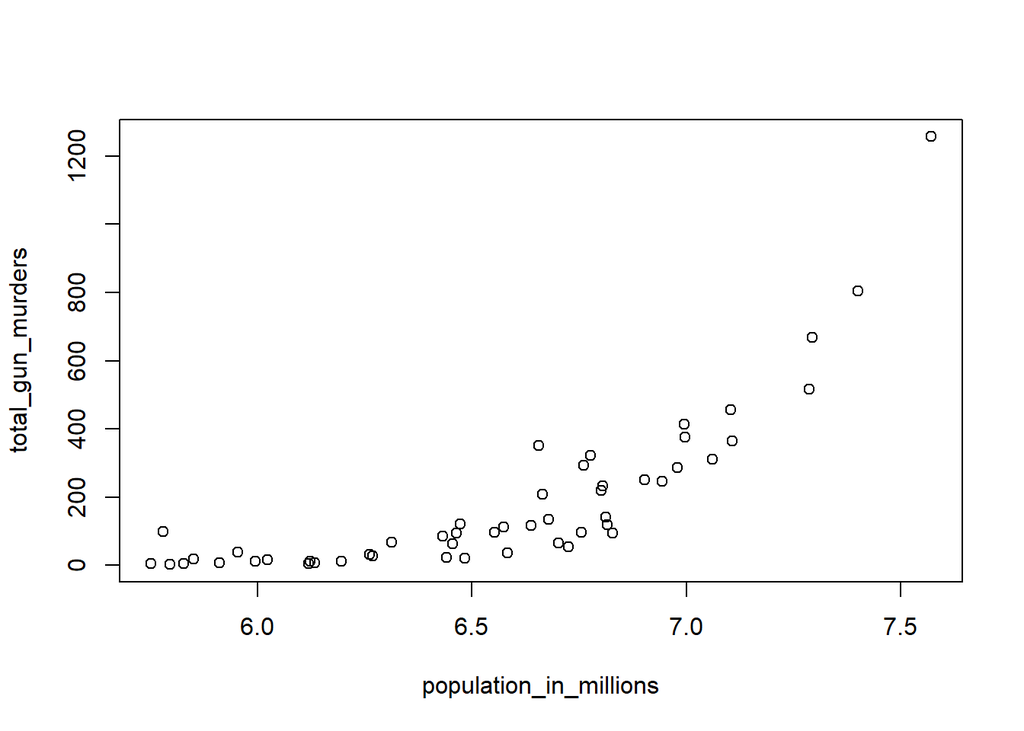

```r
population_in_millions <- log10(murders$population)
total_gun_murders <- murders$total
plot(population_in_millions, total_gun_murders)
```

# Nomor 8

Histogram dari populasi negara bagian

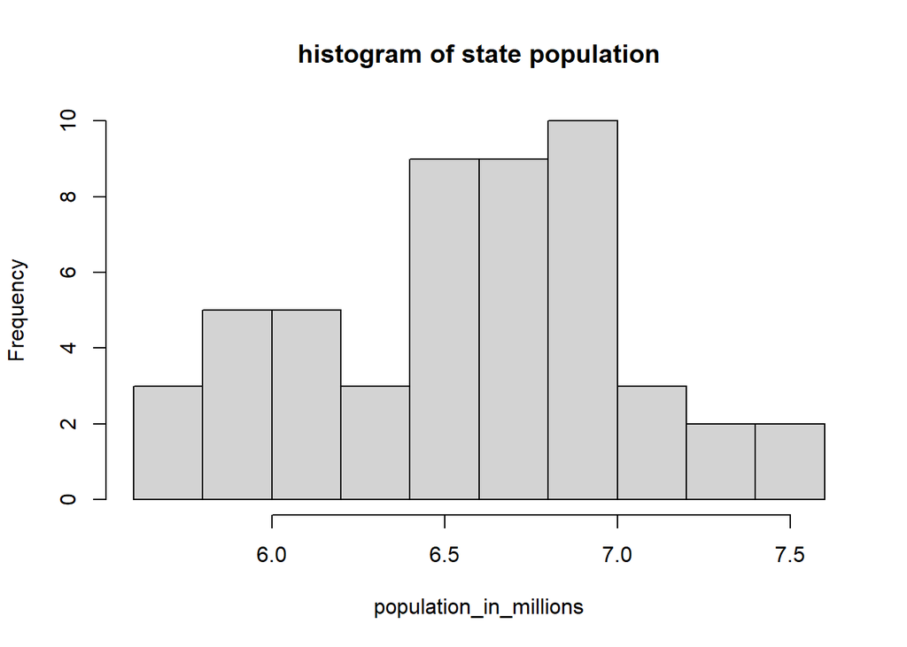

```r
population_in_millions = log10(murders$population)
hist(population_in_millions, main="histogram of state population")
```

# Nomor 9

Boxplot dari populsi negara bagian

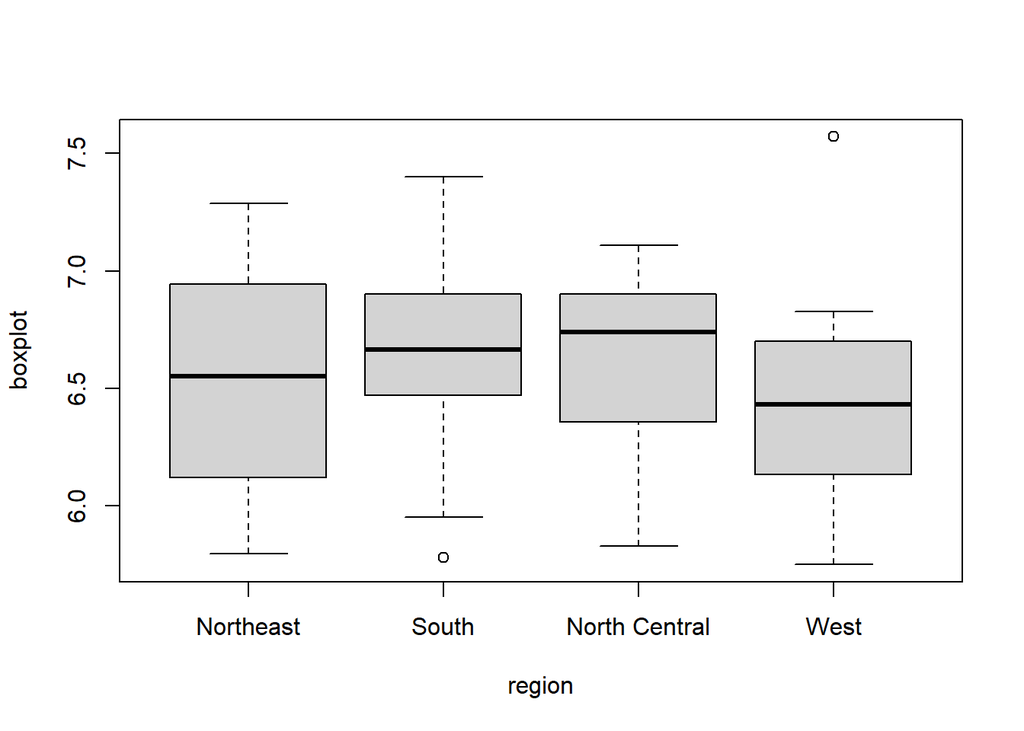

```r
murders$boxplot <- with(murders, log10(population))
boxplot(boxplot~region, data = murders)
```